# Premier League Predictive Model

Nick Bermingham

3/22/2020

### Introduction

The purpose of this paper is to generate a simple predictive model from past Premier League season data. I use season data from the 2013-2014 season up to the most recent 2018-2019 season. I have generated a Defense, Offense, and Overall score, out of 10, for each Premier League team. I use an exponential model to weight each game, so games closer to the beginning of the upcoming season are weighted more heavily. I then use these values, as well as the market value of the teams at the beginning of the 2019-2020 season, to compute a overall score for each team. This score is a relative value - higher scores mean a higher chance of winning the 2019-2020 season. The team with the highest score is, according to this model, most likely to win.

### Datasets

I start off by importing a dataset from each of the past six seasons. Each dataset is comprised of a each game’s relevant statistic: Date, Teams, Referee, Goals at Halftime, Goals at Full Time, and result. Other statistics in the data are ignored. I also import a dataset of teams and their respective Market Value, in euros, at the beginning of the 2019-2020 season. For aesthetic purposes, I added hex color codes for the main team color of each of the premier league teams. I couldn’t find a dataset online with all of these codes, so I added them into the code manually. These colors are included in the referee bar chart.

```
##       Date   HomeTeam    AwayTeam FTHG FTAG FTR HTHG HTAG HTR     Referee
## 1 17/08/13    Arsenal Aston Villa    1    3   A    1    1   D    A Taylor
## 2 17/08/13  Liverpool       Stoke    1    0   H    1    0   H  M Atkinson
## 3 17/08/13    Norwich     Everton    2    2   D    0    0   D    M Oliver
## 4 17/08/13 Sunderland      Fulham    0    1   A    0    0   D N Swarbrick
## 5 17/08/13    Swansea  Man United    1    4   A    0    2   A      P Dowd
## 6 17/08/13  West Brom Southampton    0    1   A    0    0   D    K Friend
```

### Data cleaning

I started off by binding all six of the season data files into a all_seasons dataframe. I create a duplicated version of that dataframe with the home and away teams switched. This allowed me to analyze each game which both teams as the home team. I then concatenated the duplicate to the original into a dataframe I called master. I then created a goal differential column, by simply subtracting the full time away goals from the full time home goals. I deemed this statistic more valuable than the full time result, which simply denotes a win loss or tie. The degree to which each team won or lost is used later to compute the referee and rivalry statistics. In order to weight each game based on how far away the game is from the beginning of the 19/20 season, I created a date difference column which calculates how many days before August 1st, 2019 the game in question was played.

```
##      Day Month Year       HomeTeam    AwayTeam FTHG FTAG FTR HTHG HTAG HTR
## 2272  12     5   19       Brighton    Man City    1    4   A    1    2   A
## 2273  12     5   19        Burnley     Arsenal    1    3   A    0    0   D
## 2274  12     5   19 Crystal Palace Bournemouth    5    3   H    3    1   H
## 2275  12     5   19         Fulham   Newcastle    0    4   A    0    2   A
## 2276  12     5   19      Leicester     Chelsea    0    0   D    0    0   D
## 2277  12     5   19      Liverpool      Wolves    2    0   H    1    0   H
##         Referee    Date date_diff  date_weight GD
## 2272   M Oliver 12/5/19   81 days 3.442477e-14 -3
## 2273     M Dean 12/5/19   81 days 3.442477e-14 -2
## 2274     R East 12/5/19   81 days 3.442477e-14  2
## 2275   K Friend 12/5/19   81 days 3.442477e-14 -4
## 2276   A Taylor 12/5/19   81 days 3.442477e-14  0
## 2277 M Atkinson 12/5/19   81 days 3.442477e-14  2
```

### Offense and Defense Ratings of each team

I created a goals_table dataframe with each team as the row names. I computed the GoalsFor statistic by multiplying each home game’s Home Goals by the date_weight, and summing them all together. The date_weight is computed by plugging in the date_difference (how far away, in days, the game was from the beginning of the 2019-2020 season) into an exponential distribution. This gives higher values for smaller inputs, meaning games closer to the beginning of the new season are weighted more heavily, while also allowing for teams that have historically been good, but have had a poor stretch in recent games, to be considered. I then calculated the GoalsAgainst column similarly. Once I have these values, I normalize them by plugging them into a normal distribution, with the mean and standard deviation of each of the columns. This gives interpretable values, from zero to one, that are relative to other team’s values. I then multiply these values by ten to get scores out of ten. These are the final offense rating and defense rating values for each team. The overall rating is computed by taking the average of these two values.

| Team | Offense Rating | Defense Rating | Overall Rating |
| --- | --- | --- | --- |
| Chelsea | 9.95 | 8.90 | 9.4 |
| West Ham | 8.70 | 9.60 | 9.1 |
| Tottenham | 7.25 | 9.60 | 8.4 |
| Liverpool | 7.05 | 9.60 | 8.3 |
| Man City | 9.95 | 6.45 | 8.2 |
| Stoke | 8.40 | 8.05 | 8.2 |
| Southampton | 7.05 | 9.00 | 8.0 |
| Cardiff | 9.60 | 5.55 | 7.6 |
| Norwich | 8.70 | 6.45 | 7.6 |
| Hull | 7.25 | 7.70 | 7.5 |
| Man United | 5.90 | 9.00 | 7.5 |
| West Brom | 5.90 | 9.00 | 7.5 |
| Sunderland | 5.90 | 8.05 | 7.0 |
| Everton | 5.90 | 7.70 | 6.8 |
| Fulham | 7.25 | 6.45 | 6.8 |
| Arsenal | 7.05 | 5.95 | 6.5 |
| Crystal Palace | 5.90 | 6.90 | 6.4 |
| Swansea | 7.25 | 5.15 | 6.2 |
| Aston Villa | 5.90 | 5.55 | 5.7 |
| Newcastle | 5.90 | 5.55 | 5.7 |

### Referee Aid Statistic

I was curious to see if there were any noteworthy team-referee relationships in the Premiership in the past six years of data. I used the HomeTeam, Referee, and GD (goal differential) columns to calculate this statistic. I grouped the master data by Home Team and Referee, and then calculated the z-score of each of these goal differentials. The z-score takes into account the mean GD, the standard deviation of goal differential across all the games, and then the number of games with the given team-referee combination. I plotted some of the highlights of these z-score values - the team-referee relationships with the highest and lowest scores.

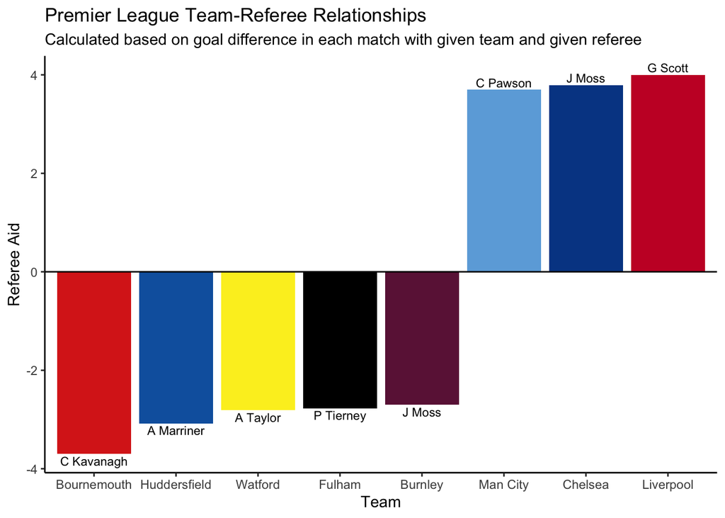

### Opponent Factor

I used a similar process to determine each teams relationship to other teams in the league. I grouped the data by home and away team, and calculated a z-score for the goal difference. For clarity, I included the number of games played, the mean goal differential, and the standard deviation along with the Opponent Factor (the computed z-score).

```r
riv_table <- master %>%
  group_by(HomeTeam, AwayTeam) %>%
  summarise(Games_Played = n(), std_dev = sd(GD), mean.GD = mean(GD),
            riv.fact = mean(GD)/(master_sd/sqrt(n()))) %>%
  select("Team" = HomeTeam, "Opponent" = AwayTeam, "Games Played" = Games_Played, "Mean Goal Differential" =
           mean.GD, "Standard Deviation" = std_dev, riv.fact) %>%
  arrange(-riv.fact)

names(riv_table)[6] <- "Opponent Factor"

riv_table %>%
  formattable(align = c("l","l","c","c","c", "r"),
              list("Games Played" = color_tile(customGreen0, customGreen),
                   "Mean Goal Differential" = color_tile(customRed, customGreen),
                   "Standard Deviation" = color_tile(customGreen, customGreen0),
                   "Opponent Factor" = color_tile(customRed, customGreen)))
```

| Team | Opponent | Games Played | Mean Goal Differential | Standard Deviation | Opponent Factor |
| --- | --- | --- | --- | --- | --- |
| Man City | Bournemouth | 8 | 2.75000000 | 1.3887301 | 4.1485842 |
| Man City | Watford | 8 | 2.62500000 | 1.8468119 | 3.9600122 |
| Man City | West Brom | 10 | 2.20000000 | 1.0327956 | 3.7106066 |
| Tottenham | Bournemouth | 8 | 2.37500000 | 2.1339099 | 3.5828682 |
| Man City | Newcastle | 10 | 2.10000000 | 2.0248457 | 3.5419426 |
| Liverpool | Watford | 8 | 2.25000000 | 2.8660575 | 3.3942962 |
| Man City | Crystal Palace | 12 | 1.83333333 | 2.0816660 | 3.3873049 |
| Man City | Swansea | 10 | 2.00000000 | 1.5634719 | 3.3732787 |
| Liverpool | Huddersfield | 4 | 3.00000000 | 1.6329932 | 3.2001732 |
| Man City | Fulham | 4 | 3.00000000 | 1.4142136 | 3.2001732 |
| Tottenham | Huddersfield | 4 | 3.00000000 | 1.1547005 | 3.2001732 |
| Man City | Southampton | 12 | 1.66666667 | 1.8257419 | 3.0793681 |
| Arsenal | Burnley | 8 | 2.00000000 | 1.4142136 | 3.0171522 |
| Arsenal | Fulham | 4 | 2.75000000 | 0.9574271 | 2.9334921 |
| Man City | West Ham | 12 | 1.58333333 | 1.6764862 | 2.9253996 |
| Tottenham | Stoke | 10 | 1.70000000 | 2.4966644 | 2.8672869 |
| Arsenal | Aston Villa | 6 | 2.16666667 | 2.4832774 | 2.8306746 |
| Tottenham | Hull | 6 | 2.16666667 | 2.1369761 | 2.8306746 |
| Liverpool | Bournemouth | 8 | 1.87500000 | 1.8850919 | 2.8285802 |
| Man United | Crystal Palace | 12 | 1.50000000 | 1.0871146 | 2.7714312 |
| Chelsea | Stoke | 10 | 1.60000000 | 2.0110804 | 2.6986230 |
| Chelsea | Brighton | 4 | 2.50000000 | 1.2909944 | 2.6668110 |
| Chelsea | Huddersfield | 4 | 2.50000000 | 2.0816660 | 2.6668110 |
| Liverpool | Cardiff | 4 | 2.50000000 | 0.5773503 | 2.6668110 |
| Liverpool | Brighton | 4 | 2.50000000 | 1.7320508 | 2.6668110 |
| Arsenal | Sunderland | 8 | 1.75000000 | 1.1649647 | 2.6400082 |
| Arsenal | West Ham | 12 | 1.41666667 | 1.8319554 | 2.6174628 |
| Arsenal | Hull | 6 | 2.00000000 | 1.0954451 | 2.6129304 |
| Man City | Stoke | 10 | 1.50000000 | 2.2730303 | 2.5299590 |
| Tottenham | Swansea | 10 | 1.50000000 | 1.4337209 | 2.5299590 |

[output cut: 716 more lines]

### Market Factor

Considering the importance of teams market power in their success, I decided to factor this into the predictive model. I read in a market value csv file with each team and their market value, in euros, and normalize the values by plugging them into a normal distribution. This gives a value, like before, for each team between 0 and 1. In future models, I’d like to perhaps consider a teams market growth as well, which was included in the csv file.

| Team | Market Value | Growth | Market Factor |
| --- | --- | --- | --- |
| Liverpool | €1.19bn | 12.3 % | 0.9941428 |
| Tottenham | €863.50m | 8.9 % | 0.9218017 |
| Chelsea | €829.05m | 8.5 % | 0.9033500 |
| Man United | €798.75m | 8.2 % | 0.8846361 |
| Arsenal | €706.75m | 7.3 % | 0.8126197 |
| Everton | €504.70m | 5.2 % | 0.5811382 |
| Leicester | €504.25m | 5.2 % | 0.5805441 |
| Wolves | €365.55m | 3.8 % | 0.3953423 |
| West Ham | €351.75m | 3.6 % | 0.3774990 |
| Bournemouth | €335.75m | 3.5 % | 0.3571361 |
| Newcastle | €307.83m | 3.2 % | 0.3225879 |
| Aston Villa | €269.90m | 2.8 % | 0.2780478 |
| Watford | €232.80m | 2.4 % | 0.2376067 |
| Brighton | €227.25m | 2.3 % | 0.2318471 |
| Southampton | €223.50m | 2.3 % | 0.2279999 |
| Crystal Palace | €215.00m | 2.2 % | 0.2194140 |
| Burnley | €195.75m | 2.0 % | 0.2006715 |
| Sheffield United | €159.35m | 1.6 % | 0.1679668 |
| Norwich City | €156.35m | 1.6 % | 0.1654335 |

## Final Analysis

```
##              Team Chance of Winning
## 1       Liverpool            15.45%
## 2         Chelsea            12.19%
## 3        West Ham            10.06%
## 4       Tottenham             9.29%
## 5     Southampton             8.84%
## 6            Hull             8.29%
## 7      Man United             8.29%
## 8      Sunderland             7.74%
## 9         Arsenal             7.19%
## 10        Everton             5.37%
## 11      Newcastle             2.74%
## 12    Aston Villa             2.41%
## 13 Crystal Palace             2.15%
```